# Linear models

Tutorial 4: exercises and solutions

Dr Massimiliano Canzi

## Setup

```r
library(tidyverse)
library(broom)
library(simling)
```

## The data

`rhythm_metrics` comes from a simulated study of speech rhythm. Eight speakers of each of six languages read sentences, told a story and spoke freely, and each of the 1200 speech samples has two measures we use today: the speech rate (`rate`, in syllables per second) and ΔC (`delta_c`, in ms). ΔC is the standard deviation of the durations of the consonant intervals in a sample, one of the rhythm metrics that phoneticians use to compare languages.

```r
glimpse(rhythm_metrics)
```

```
Rows: 1,200
Columns: 8
$ language  <fct> English, English, English, English, English, Engli…
$ speaker   <fct> eng_01, eng_01, eng_01, eng_01, eng_01, eng_01, en…
$ material  <fct> complex-syllable sentences, complex-syllable sente…
$ item      <int> 1, 2, 3, 4, 5, 1, 2, 3, 4, 5, 1, 2, 3, 4, 5, 1, 2,…
$ rate      <dbl> 5.55, 4.89, 5.14, 4.88, 5.44, 5.46, 5.49, 4.99, 5.…
$ percent_v <dbl> 37.1, 38.7, 38.1, 34.6, 39.1, 44.4, 49.0, 52.0, 43…
$ delta_c   <dbl> 56.8, 57.5, 54.6, 57.5, 59.0, 49.3, 40.2, 44.1, 50…
$ varco_v   <dbl> 65.4, 59.7, 56.1, 66.0, 52.8, 50.8, 50.7, 55.0, 51…
```

Today’s question: does ΔC change with speech rate?

# 1. Look before you fit

## 1.1 A scatterplot

Plot `delta_c` against `rate` with `geom_point()`, with speech rate on the `x` axis. Label both axes in words, with units. Do faster samples have a larger or a smaller ΔC?

## 1.1 Solution

```r
rhythm_metrics |>
  ggplot(aes(x = rate, y = delta_c)) +
  geom_point(colour = "plum2", alpha = 0.3) +
  xlab("Speech rate (syllables per second)") + ylab("ΔC (ms)")
```

## 1.1 Solution

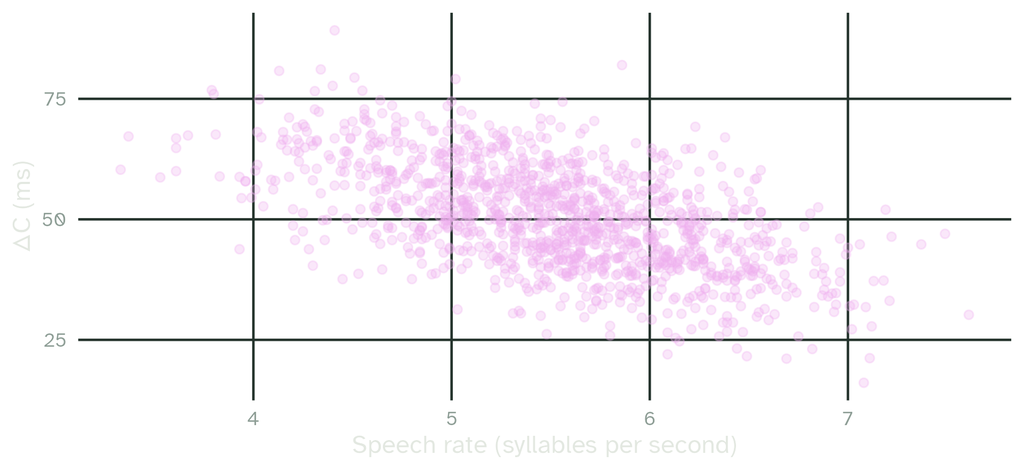

The faster the sample, the smaller ΔC tends to be. The points form a roughly straight cloud, so a line is a reasonable first model.

## 1.2 Add the line

Add the regression line with `geom_smooth(method = "lm")`.

## 1.2 Solution

```r
rhythm_metrics |>
  ggplot(aes(x = rate, y = delta_c)) +
  geom_point(colour = "plum2", alpha = 0.3) +
  geom_smooth(method = "lm") +
  xlab("Speech rate (syllables per second)") + ylab("ΔC (ms)")
```

## 1.2 Solution

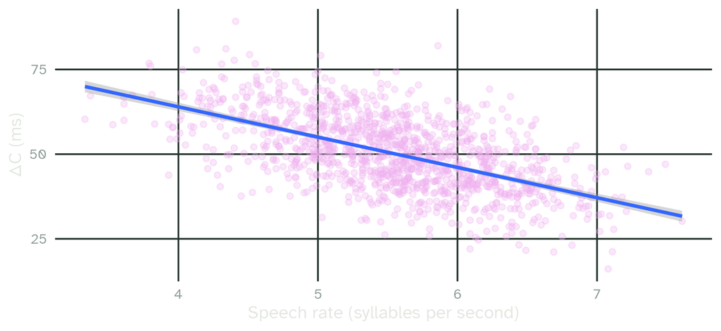

# 2. Fitting the model

## 2.1 `lm()`

Fit a linear model of `delta_c` as a function of `rate` and save it as `m`. Print its coefficients with `coef()`.

## 2.1 Solution

```r
m <- lm(delta_c ~ rate, data = rhythm_metrics)
coef(m)
```

```
(Intercept)        rate
  99.730026   -8.941649
```

## 2.2 Read the coefficients

Complete the sentence: “With every extra syllable per second, ΔC changes by ___ ms.” Then say what the intercept means here. Is it a useful number?

## 2.2 Solution

With every extra syllable per second, ΔC falls by 8.9 ms.

The intercept, 99.7 ms, is the predicted ΔC for a sample spoken at 0 syllables per second, that is, for no speech at all. The slowest sample in the data has 3.33 syllables per second, so the intercept lies far outside the data. It only sets the height of the line.

## 2.3 Model fit

Find `R²` with `glance()`. What does it tell you?

## 2.3 Solution

```r
glance(m)$r.squared
```

```
[1] 0.3232922
```

Speech rate accounts for about 32% of the variance in ΔC. The rest comes from everything the model leaves out: the language, the speaker, the kind of speech material and random variation.

# 3. Predictions and residuals

## 3.1 Predictions

Which ΔC does the model predict for samples spoken at 4 and at 6 syllables per second? Use `predict()`, with the two rates in a tibble passed to `newdata`.

## 3.1 Solution

```r
predict(m, newdata = tibble(rate = c(4, 6)))
```

```
       1        2
63.96343 46.08013
```

Two syllables per second more means a ΔC about 18 ms smaller, which is twice the slope.

## 3.2 Residuals

Use `augment()` to add the fitted values and the residuals to the data. Plot the residuals (`.resid`) against the fitted values (`.fitted`) and add a horizontal line at 0 with `geom_hline()`. Are the residuals spread evenly around 0?

## 3.2 Solution

```r
augment(m) |>
  ggplot(aes(x = .fitted, y = .resid)) +
  geom_point(colour = "plum2", alpha = 0.3) +
  geom_hline(yintercept = 0) +
  xlab("Fitted ΔC (ms)") + ylab("Residual (ms)")
```

## 3.2 Solution

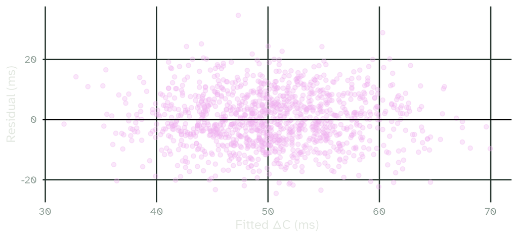

The residuals scatter around 0 with about the same spread across the fitted values, with no curve or funnel.

## 3.3 Bonus: a hidden group

Draw the scatterplot again, with the points coloured by `material` and one line per material: `geom_smooth(method = "lm", se = FALSE)`. Are the lines within each material steeper or shallower than the line of `m`?

## 3.3 Solution

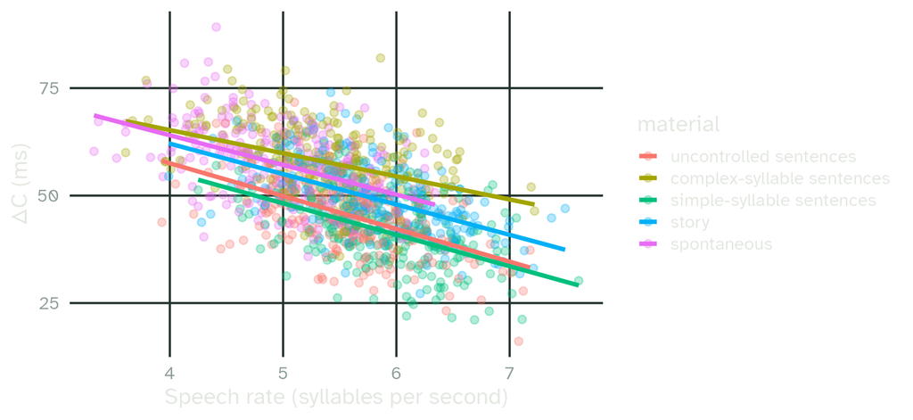

```r
rhythm_metrics |>
  ggplot(aes(x = rate, y = delta_c, colour = material)) +
  geom_point(alpha = 0.3) +
  geom_smooth(method = "lm", se = FALSE) +
  xlab("Speech rate (syllables per second)") + ylab("ΔC (ms)") +
  theme(legend.position = "right")
```

## 3.3 Solution

```r
rhythm_metrics |>
  summarise(slope = coef(lm(delta_c ~ rate))[2], .by = material)
```

```
# A tibble: 5 × 2
  material                   slope
  <fct>                      <dbl>
1 complex-syllable sentences -5.38
2 simple-syllable sentences  -7.32
3 spontaneous                -6.90
4 story                      -7.07
5 uncontrolled sentences     -7.63
```

All the lines within a material are shallower than the line of `m`, with its slope of -8.9 ms per syllable per second. Sentences built from simple syllables are read fastest and have few consonant clusters, so they have a small ΔC; spontaneous speech is slowest and has a large ΔC. Across materials, these differences add to the effect of rate. In the simulation, ΔC falls by 6 ms per syllable per second (`?rhythm_metrics`). Lectures 6 and 7 show how to put both predictors in one model.

## 3.4 Bonus: R² by hand

`R²` compares the residuals of `m` with those of an intercept-only model, `delta_c ~ 1`, which predicts the mean ΔC for every sample. Fit it and compute `R²` by hand as 1 minus the sum of the squared residuals of `m`, divided by the sum of the squared residuals of the intercept-only model. Do you get the same number as `glance()`?

## 3.4 Solution

```r
m0 <- lm(delta_c ~ 1, data = rhythm_metrics)
1 - sum(residuals(m)^2) / sum(residuals(m0)^2)
```

```
[1] 0.3232922
```

```r
glance(m)$r.squared
```

```
[1] 0.3232922
```

The two numbers are the same.

# 4. Weekly assignment

Exercises 4.1 to 4.3 are this week’s assignment. Complete them at home, in a file started from the konstats template “Weekly assignment” (tutorial 1), and hand in the .Rmd file within a week.

`freq_length` from `{simling}` has 400 words from a simulated lexical decision task. For each word, it gives its log10 frequency (`log_freq`) and the mean reaction time to it (`rt`, in ms).

## 4.1 Frequency and reaction time

Make a scatterplot of `rt` against `log_freq`, with the regression line and both axes labelled in words, with units. Do frequent words get faster or slower responses?

## 4.2 The model

Fit a linear model of `rt` as a function of `log_freq` and print its coefficients. Report the slope in a sentence, with its units. What does the intercept mean here, and is it a useful number?

## 4.3 How far can you predict?

Predict the reaction time for words with a log frequency of 2 and of 5. Then predict it for a log frequency of 8. Would you trust the third prediction? Explain why in one or two sentences.

## Reading

This tutorial goes with chapter 4 of Winter (2019).

Winter, B. (2019). *Statistics for linguists: An introduction using R*. Routledge. https://doi.org/10.4324/9781315165547

## Slides and exercises

[figure not shown]

These slides

mcanzi.de/statistics/tutorials/04_linear_models.html

Exercise sheet (R Markdown)

mcanzi.de/statistics/tutorials/04_linear_models.Rmd